# Fitting a GAM to Terra Climate data

Dr. Greg Torda

2024-11-13

# Background

A bit of background on TerraClimate, Generalized Additive Models, detrending, and why we are doing this whole exercise.

[TerraClimate](https://www.climatologylab.org/terraclimate.html) is a fantastic dataset for global climate and hydrology, offering monthly data from 1958 to the present at a ~4 km resolution. It covers key variables like precipitation, temperature (minimum, maximum), evapotranspiration, water deficit, and snow water equivalent, making it a go-to source for understanding climate patterns across time and space.

[Generalized Additive Models (GAMs)](https://www.datacamp.com/tutorial/gams-in-r) are great for working with climate data because they handle non-linear relationships really well. When looking at time series like those in TerraClimate, GAMs help separate short-term cyclical patterns (like monthly or seasonal changes) from the underlying long-term trends. By detrending the seasonal cycles, we can focus on what’s happening over decades—essentially zooming in on the big picture while still respecting the natural ebb and flow of climate data.

So in this tutorial we will see how we can access TerraClimate data via R, specifically for a single pair of coordinates, and analyse the long-term trends by fitting a detrended GAM on the time-series data.  
You can click on the ‘Show’ button to see the code.

# Preparations

Load the necessary libraries.

```r
library(colorspace)
library(lubridate)
library(tidyverse)
library(knitr)     #for kable
library(effects)   #for partial effects plots
library(mgcv)      #for GAMs
library(gratia)    #for GAM plots
library(DHARMa)    #for residuals diagnostics
library('tidygeocoder')
library(sf)
library(climateR)
library(colorjam)
theme_set(theme_bw())
```

# Getting the data from TerraClimate

```r
TSV <- tibble(Town = 'Townsville', Country = 'Australia') %>%
  geocode(Town, method = 'osm', lat = Lat , long = Long) %>%
  filter(!is.na(Lat)) %>%
  st_as_sf(coords = c("Long", "Lat"),
           crs = 4326)

TSV %>%
  kable()
```

| Town | Country | geometry |
| --- | --- | --- |
| Townsville | Australia | POINT (146.824 -19.25694) |

Then, we use the TSV simple feature object to download some climate variables from TerraClimate, using the getTerraClim function from *climateR*. For the sake of this exercise let’s download the following:

```r
variables = tibble(var = c("ppt", "tmax", "tmin"),
                   variable = c('Monthly total precipitation (mm)',
                                'Monthly average maximum temperature (°C)',
                                'Monthly average minimum temperature (°C)'))

variables %>% kable()
```

| var | variable |
| --- | --- |
| ppt | Monthly total precipitation (mm) |
| tmax | Monthly average maximum temperature (°C) |
| tmin | Monthly average minimum temperature (°C) |

We will download these variables for the full duration of the dataset, from 1958 to 2023.

```r
data <- getTerraClim(AOI = TSV,  # Townsville sf
                     varname = c('tmin', 'tmax', 'ppt'), #these are some variables from TerraClim
                     startDate = "1958-01-01",
                     endDate = "2023-12-31") %>%
  as_tibble()

head(data) %>%
  kable()
```

| date | ppt_total | tmax_total | tmin_total |
| --- | --- | --- | --- |
| 1958-01-01 | 191.4 | 32.31 | 23.35 |
| 1958-02-01 | 1082.5 | 30.79 | 23.48 |
| 1958-03-01 | 582.0 | 31.99 | 23.01 |
| 1958-04-01 | 163.2 | 29.53 | 21.26 |
| 1958-05-01 | 21.6 | 28.96 | 19.10 |
| 1958-06-01 | 63.0 | 25.94 | 16.27 |

# Quick plots

Now let’s make a quick plot to see what the data and a GAM-style smoother would look like. We will plot only the Mean Maximum Daily Temperatures (tmax) and the Mean Minimum Daily Temperatures (tmin) now, because they are on the same scale, while Precipitation (ppt) is on a different scale

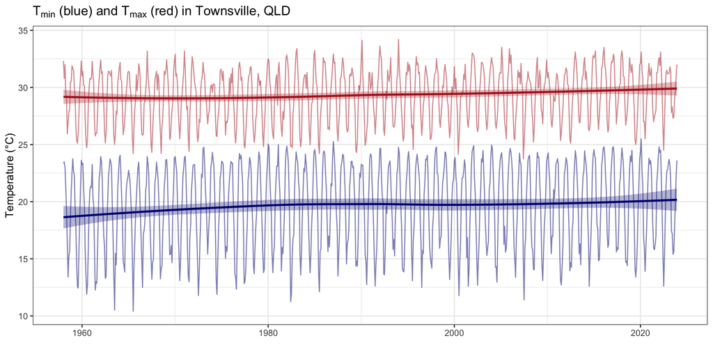

```r
data %>%
  ggplot(aes(x = date)) +
  geom_line(aes(y = tmax_total), color = 'firebrick', alpha = 0.5) +
  geom_line(aes(y = tmin_total), color = 'navyblue', alpha = 0.5) +
  geom_smooth(aes(y = tmax_total), color = 'firebrick', fill = 'firebrick', alpha = 0.3) +
  geom_smooth(aes(y = tmin_total), color = 'navyblue', fill = 'navyblue', alpha = 0.3) +
  labs(x = '', y = "Temperature (\u00B0C)") +
  ggtitle(expression(paste('T'[min], ' (blue) and T'[max], ' (red) in Townsville, QLD'))) +
  theme_bw()
```

And for fun, we can also make a heatmap-style plot with years on the x axis, months on the y axis, and the values as colors. We will plot the Mean Maximum Daily Temperatures for this exercise.

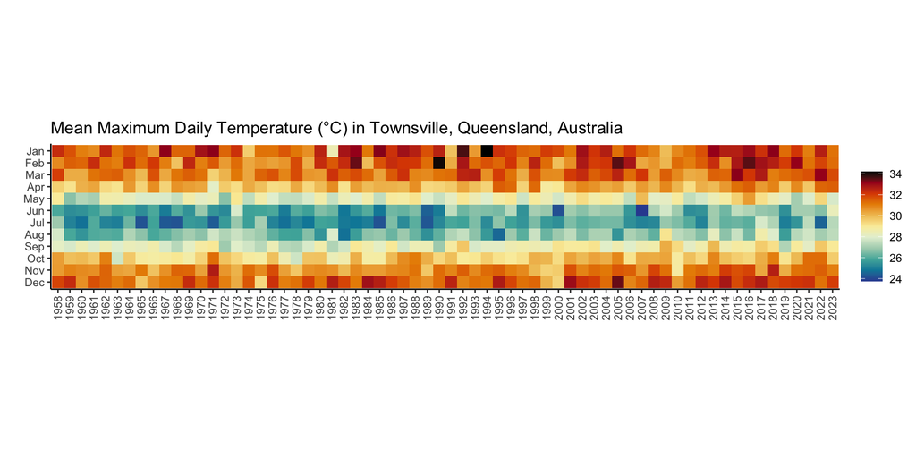

```r
data %>%
  mutate(date = as.Date(date),
         Year = factor(year(date)),
         Month = fct_rev(month(date, label = T, abbr = T))) %>%

  ggplot(aes(Year, Month, fill = tmax_total)) +
  geom_tile() +
  theme_classic() +
  scale_fill_gradientn(colors = c(rev(divergingx_hcl(10, palette = "RdYlBu")), 'black')) +
  coord_equal() +
  theme(axis.text.x = element_text(angle = 90, hjust = 1, vjust = 0.5)) +
  labs(x = '', y = '', fill = '') +
  ggtitle(label = 'Mean Maximum Daily Temperature (\u00B0C) in Townsville, Queensland, Australia')
```

# Fitting a GAM

Now let’s fit a GAM. First, should can check the distribution of the data to make an informed decision about family selection.

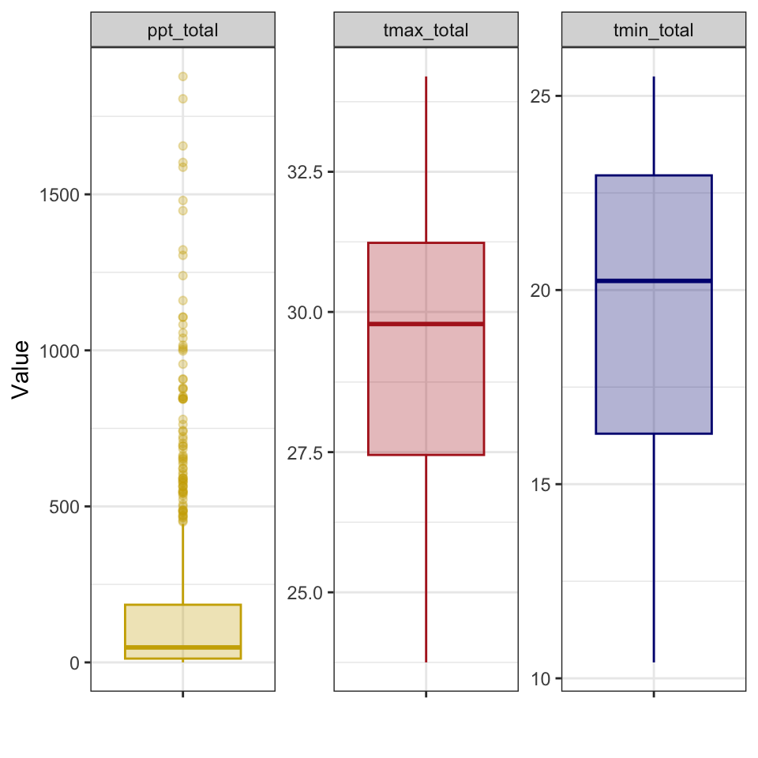

```r
data %>%
  pivot_longer(cols = contains('_total'), names_to = 'Parameter', values_to = 'Value') %>%
  ggplot(aes('', Value, color = Parameter, fill = Parameter)) +
  geom_boxplot(alpha = 0.3, show.legend = F) +
  facet_wrap(~Parameter, scales = 'free') +
  scale_fill_manual(values = c('gold3', 'firebrick', 'navyblue')) +
  scale_color_manual(values = c('gold3', 'firebrick', 'navyblue')) +
  labs(x = '') +
  theme_bw()
```

We see that the two temperature parameters are more or less normally distributed, while precipitation is skewed (and of course bound by 0).  
For this exercise, let’s just fit a gaussian GAM to the tmax data.  
**Note that we will use a *cyclic cubic regression spline* for the smoother of months.** This way we account for a cyclic seasonal change.

```r
tmax <- data %>%
  dplyr::select(date, tmax_total) %>%
  mutate(Date = as.Date(date),
         Date_numeric = decimal_date(date), # Numeric date for modeling
         Year = year(Date),          # Extract Year
         Month = month(Date, label = TRUE, abbr = TRUE),
         Month_numeric = month(Date)) # Numeric month for continuity

tmax.gam <- gam(tmax_total ~ s(Date_numeric) + s(Month_numeric, bs='cc', k = 10),
               data = tmax, family = gaussian, method = 'REML')
```

# Model validation

Let’s check if the ‘wiggliness’ of the GAM was sufficient:

```r
k.check(tmax.gam) %>%
  kable()
```

|  | k’ | edf | k-index | p-value |
| --- | --- | --- | --- | --- |
| s(Date_numeric) | 9 | 2.302320 | 0.6314509 | 0.000 |
| s(Month_numeric) | 8 | 7.410729 | 1.0213362 | 0.675 |

The degrees of freedom (k’) is the nominated k minus 1 (or minus 2 for cyclic cubic regression spline, because the cyclic constraint requires extra parameters to enforce continuity at the boundaries).  
So it says we started with 8 degrees of freedom, then it says what would be the optimum… edf = 7.4 (estimated degree of freedom). It is pretty close to the 8 that we started with. Ideally we want it to be quite a bit lower than k’. k index needs to be greater than 1 and p value to be greater than 0.05. If multiples of these turn out to be untrue, there was a problem. Here we are in the clear because the s(Date_numeric) is a ‘detrended’ component, and we don’t expect the GAM to actually follow the wiggliness of the original data, we expect it to be ‘over-smoothed’.

Then, let’s check the fit:

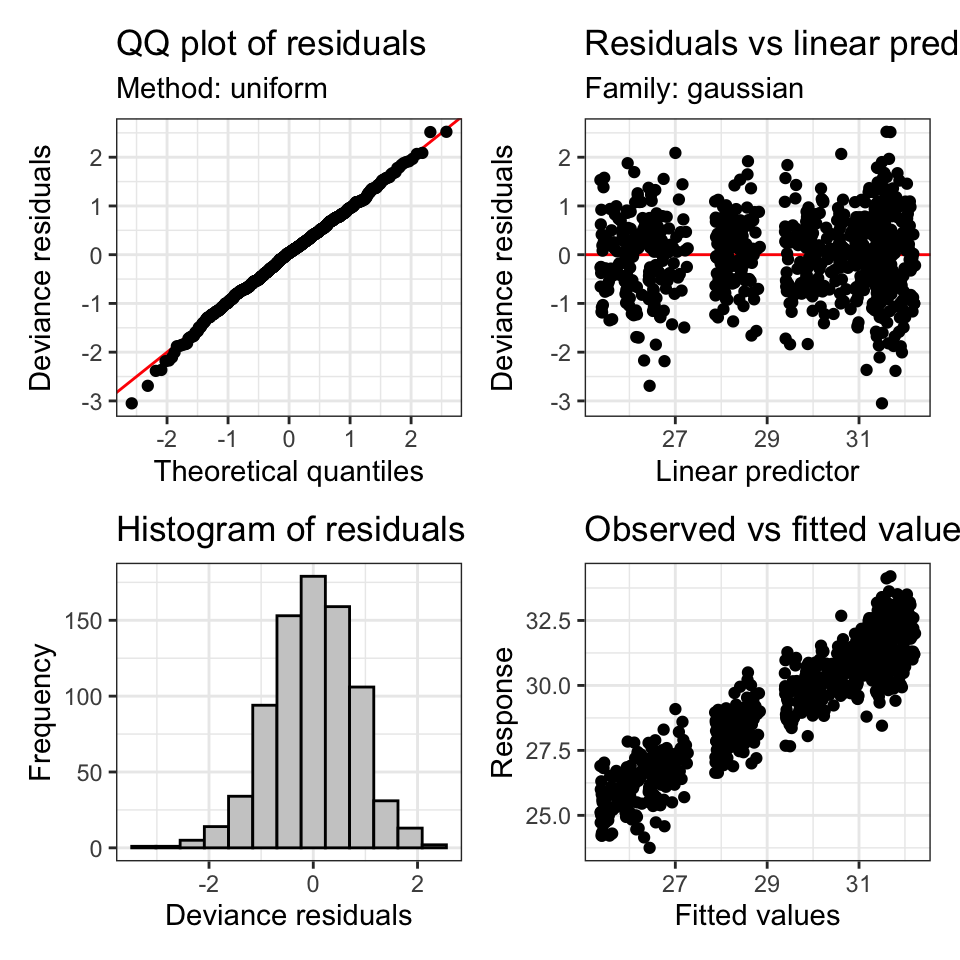

```r
appraise(tmax.gam)
```

Here we want to see a good fit on the QQ plot, no pattern on the residuals vs linear predictor plot, a rather gaussian histogram of residuals, reasonable match between observed and fitted values. It all looks fantastic herem so we can go ahead and summarise the model.

# Model summary

As a cheeky glimpse, we can also have a quick look at the partial effects of the two components, the detrended, long-term change over years (the smoother for Date_numeric) and the cyclic seasonality (the smoother for Month_numeric).

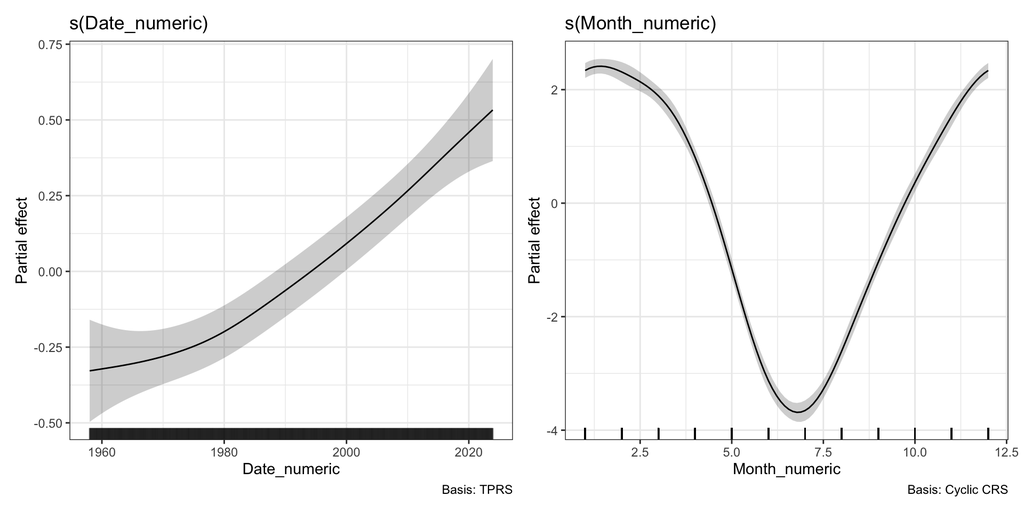

```r
gratia::draw(tmax.gam)
```

And we can summarise the model.

```r
summary(tmax.gam)
```

```
##
## Family: gaussian
## Link function: identity
##
## Formula:
## tmax_total ~ s(Date_numeric) + s(Month_numeric, bs = "cc", k = 10)
##
## Parametric coefficients:
##             Estimate Std. Error t value Pr(>|t|)
## (Intercept) 29.34922    0.02842    1033   <2e-16 ***
## ---
## Signif. codes:  0 '***' 0.001 '**' 0.01 '*' 0.05 '.' 0.1 ' ' 1
##
## Approximate significance of smooth terms:
##                    edf Ref.df      F p-value
## s(Date_numeric)  2.302   2.87  30.66  <2e-16 ***
## s(Month_numeric) 7.411   8.00 714.42  <2e-16 ***
## ---
## Signif. codes:  0 '***' 0.001 '**' 0.01 '*' 0.05 '.' 0.1 ' ' 1
##
## R-sq.(adj) =   0.88   Deviance explained = 88.1%
## -REML = 967.76  Scale est. = 0.63959   n = 792
```

We can see that both the long term trend and the seasonal trends were significant, and the model explains 88.1% of the variation.

# Predictions and final plots

Now we want to make predictions and plot the long term smoother over the data. We will need to define which month(s) we want to make the predicitons for. By default, it would be made on the mean of the numeric months, which is not very meaningful (=6.5), so instead we will make predicitons for January, April, July and October.

```r
# get our sequence of dates
newdata <- data.frame(
  Date_numeric = seq(min(tmax$Date_numeric), max(tmax$Date_numeric), length.out = 100),
  Month_numeric = c(1, 4, 7, 10)) %>% # Or a fixed value #mean(tmax$Month_numeric
  as_tibble()

# get predictions
predictions <- predict(tmax.gam, newdata = newdata, type = "response", se.fit = TRUE)

# add predictions and confidence intervals to the data frame
newdata <- newdata %>%
  mutate(
    fit = as.numeric(predictions$fit),
    lower.CL = as.numeric(predictions$fit - 1.96 * predictions$se.fit),
    upper.CL = as.numeric(predictions$fit + 1.96 * predictions$se.fit),
    Month = month(Month_numeric, label = T)
  )

head(newdata) %>%
  kable()
```

| Date_numeric | Month_numeric | fit | lower.CL | upper.CL | Month |
| --- | --- | --- | --- | --- | --- |
| 1958.000 | 1 | 31.35888 | 31.15231 | 31.56544 | Jan |
| 1958.666 | 4 | 29.83067 | 29.61489 | 30.04645 | Apr |
| 1959.332 | 7 | 25.37099 | 25.14179 | 25.60019 | Jul |
| 1959.997 | 10 | 29.38908 | 29.17907 | 29.59908 | Oct |
| 1960.663 | 1 | 31.36730 | 31.18300 | 31.55160 | Jan |
| 1961.329 | 4 | 29.83916 | 29.64248 | 30.03584 | Apr |

We can define a color scheme for the four months we made predictions for, and plot the predicted values.

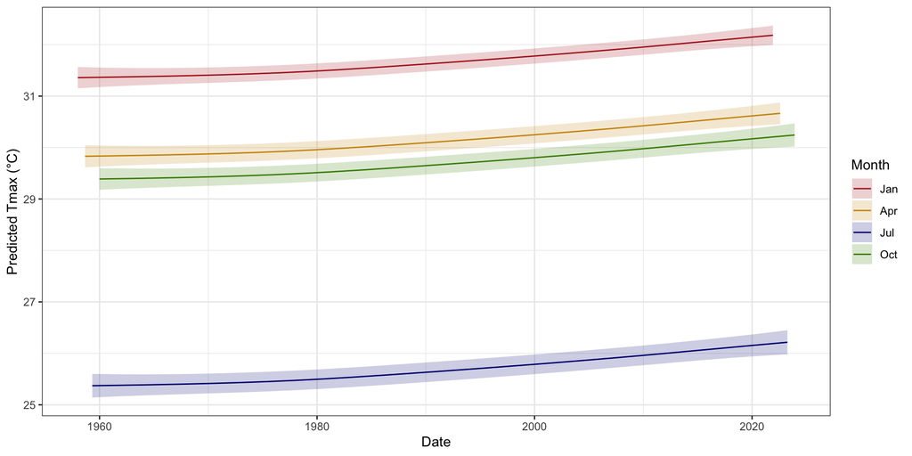

```r
monthColors <- setNames(c('firebrick', 'darkgoldenrod3', 'navyblue', 'chartreuse4'), unique(newdata$Month))

# Plot
newdata %>%
ggplot(aes(x = Date_numeric, y = fit, group = Month, fill = Month, color = Month)) +
  geom_ribbon(aes(ymin = lower.CL, ymax = upper.CL), alpha = 0.2, color = NA) +
  geom_line() +
  labs(y = "Predicted Tmax (°C)", x = "Date") +
  scale_color_manual(values = monthColors) +
  scale_fill_manual(values = monthColors) +
  theme_bw()
```

And now let’s make the final plot with the actual data and the predictions for the four months, color coded as before.

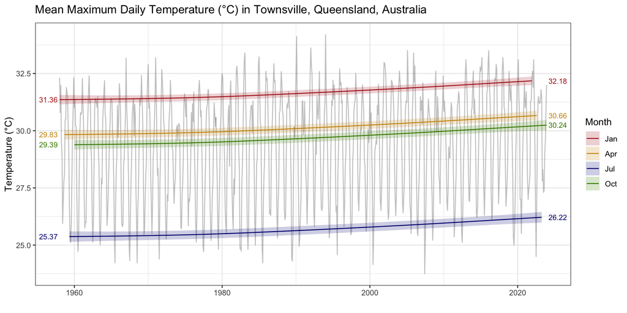

```r
newdata %>%
  ggplot(aes(x = Date_numeric)) +
  geom_line(data = tmax, aes(y = tmax_total), color = 'gray20', alpha = 0.3) +
  geom_ribbon(aes(ymin = lower.CL, ymax = upper.CL, group = Month, fill = Month), alpha= 0.2) +
  geom_line(aes(x = Date_numeric, y = fit, group = Month, color = Month)) +
  annotate("text", x = 1958, y = newdata$fit[1:4], label = round(newdata$fit[1:4], 2), hjust = 1.1, color = monthColors, size = 3) +
  annotate("text", x = max(newdata$Date_numeric), y = tail(newdata$fit, 4), label = round(tail(newdata$fit, 4), 2), hjust = -0.1, color = monthColors, size = 3) +
  labs(x = '', y = "Temperature (\u00B0C)") +
  scale_color_manual(values = monthColors) +
  scale_fill_manual(values = monthColors) +
  ggtitle(expression(paste('Mean Maximum Daily Temperature (\u00B0C) in Townsville, Queensland, Australia'))) +
  theme_bw()
```

There, we can say that there is a significant increase in mean daily maximum temperature over the course of the last 65 years, and we have a nice figure to go with this statement. :)

Next we will build a Shiny App to do the same analysis to any user-selected coordinates on the globe. But that is for next time.  
Cheerio!